# SocGen Case Study

by-

Soumojit Chatterjee(222PGF025)

# Importing Libraries & Data

```python
import pandas as pd
import numpy as np
import numpy as np
import pandas as pd
import matplotlib.pyplot as plt
import seaborn as sns
import scipy.stats as stats
from numpy.random import randint
import os
from sklearn.impute import SimpleImputer
```

```python
os.getcwd()
os.chdir("D:\python\Case Study SocGen")
```

```python
application_train = pd.read_csv('./application_train.csv')
application_train
```

|  | SK_ID_CURR | TARGET | NAME_CONTRACT_TYPE | CODE_GENDER | FLAG_OWN_CAR | FLAG_OWN_REALTY | CNT_CHILDREN | AMT_INCOME_TOTAL | AMT_CREDIT | AMT_ANNUITY | ... | FLAG_DOCUMENT_18 | FLAG_DOCUMENT_19 | FLAG_DOCUMENT_20 | FLAG_DOCUMENT_21 | AMT_REQ_CREDIT_BUREAU_HOUR | AMT_REQ_CREDIT_BUREAU_DAY | AMT_REQ_CREDIT_BUREAU_WEEK | AMT_REQ_CREDIT_BUREAU_MON | AMT_REQ_CREDIT_BUREAU_QRT | AMT_REQ_CREDIT_BUREAU_YEAR |
| --- | --- | --- | --- | --- | --- | --- | --- | --- | --- | --- | --- | --- | --- | --- | --- | --- | --- | --- | --- | --- | --- |
| 0 | 100002 | 1 | Cash loans | M | N | Y | 0 | 202500.0 | 406597.5 | 24700.5 | ... | 0 | 0 | 0 | 0 | 0.0 | 0.0 | 0.0 | 0.0 | 0.0 | 1.0 |
| 1 | 100003 | 0 | Cash loans | F | N | N | 0 | 270000.0 | 1293502.5 | 35698.5 | ... | 0 | 0 | 0 | 0 | 0.0 | 0.0 | 0.0 | 0.0 | 0.0 | 0.0 |
| 2 | 100004 | 0 | Revolving loans | M | Y | Y | 0 | 67500.0 | 135000.0 | 6750.0 | ... | 0 | 0 | 0 | 0 | 0.0 | 0.0 | 0.0 | 0.0 | 0.0 | 0.0 |
| 3 | 100006 | 0 | Cash loans | F | N | Y | 0 | 135000.0 | 312682.5 | 29686.5 | ... | 0 | 0 | 0 | 0 | NaN | NaN | NaN | NaN | NaN | NaN |
| 4 | 100007 | 0 | Cash loans | M | N | Y | 0 | 121500.0 | 513000.0 | 21865.5 | ... | 0 | 0 | 0 | 0 | 0.0 | 0.0 | 0.0 | 0.0 | 0.0 | 0.0 |
| ... | ... | ... | ... | ... | ... | ... | ... | ... | ... | ... | ... | ... | ... | ... | ... | ... | ... | ... | ... | ... | ... |
| 307506 | 456251 | 0 | Cash loans | M | N | N | 0 | 157500.0 | 254700.0 | 27558.0 | ... | 0 | 0 | 0 | 0 | NaN | NaN | NaN | NaN | NaN | NaN |
| 307507 | 456252 | 0 | Cash loans | F | N | Y | 0 | 72000.0 | 269550.0 | 12001.5 | ... | 0 | 0 | 0 | 0 | NaN | NaN | NaN | NaN | NaN | NaN |
| 307508 | 456253 | 0 | Cash loans | F | N | Y | 0 | 153000.0 | 677664.0 | 29979.0 | ... | 0 | 0 | 0 | 0 | 1.0 | 0.0 | 0.0 | 1.0 | 0.0 | 1.0 |
| 307509 | 456254 | 1 | Cash loans | F | N | Y | 0 | 171000.0 | 370107.0 | 20205.0 | ... | 0 | 0 | 0 | 0 | 0.0 | 0.0 | 0.0 | 0.0 | 0.0 | 0.0 |
| 307510 | 456255 | 0 | Cash loans | F | N | N | 0 | 157500.0 | 675000.0 | 49117.5 | ... | 0 | 0 | 0 | 0 | 0.0 | 0.0 | 0.0 | 2.0 | 0.0 | 1.0 |

307511 rows × 122 columns

```python
application_test = pd.read_csv('./application_test.csv')
application_test
```

|  | SK_ID_CURR | NAME_CONTRACT_TYPE | CODE_GENDER | FLAG_OWN_CAR | FLAG_OWN_REALTY | CNT_CHILDREN | AMT_INCOME_TOTAL | AMT_CREDIT | AMT_ANNUITY | AMT_GOODS_PRICE | ... | FLAG_DOCUMENT_18 | FLAG_DOCUMENT_19 | FLAG_DOCUMENT_20 | FLAG_DOCUMENT_21 | AMT_REQ_CREDIT_BUREAU_HOUR | AMT_REQ_CREDIT_BUREAU_DAY | AMT_REQ_CREDIT_BUREAU_WEEK | AMT_REQ_CREDIT_BUREAU_MON | AMT_REQ_CREDIT_BUREAU_QRT | AMT_REQ_CREDIT_BUREAU_YEAR |
| --- | --- | --- | --- | --- | --- | --- | --- | --- | --- | --- | --- | --- | --- | --- | --- | --- | --- | --- | --- | --- | --- |
| 0 | 100001 | Cash loans | F | N | Y | 0 | 135000.0 | 568800.0 | 20560.5 | 450000.0 | ... | 0 | 0 | 0 | 0 | 0.0 | 0.0 | 0.0 | 0.0 | 0.0 | 0.0 |
| 1 | 100005 | Cash loans | M | N | Y | 0 | 99000.0 | 222768.0 | 17370.0 | 180000.0 | ... | 0 | 0 | 0 | 0 | 0.0 | 0.0 | 0.0 | 0.0 | 0.0 | 3.0 |
| 2 | 100013 | Cash loans | M | Y | Y | 0 | 202500.0 | 663264.0 | 69777.0 | 630000.0 | ... | 0 | 0 | 0 | 0 | 0.0 | 0.0 | 0.0 | 0.0 | 1.0 | 4.0 |
| 3 | 100028 | Cash loans | F | N | Y | 2 | 315000.0 | 1575000.0 | 49018.5 | 1575000.0 | ... | 0 | 0 | 0 | 0 | 0.0 | 0.0 | 0.0 | 0.0 | 0.0 | 3.0 |
| 4 | 100038 | Cash loans | M | Y | N | 1 | 180000.0 | 625500.0 | 32067.0 | 625500.0 | ... | 0 | 0 | 0 | 0 | NaN | NaN | NaN | NaN | NaN | NaN |
| ... | ... | ... | ... | ... | ... | ... | ... | ... | ... | ... | ... | ... | ... | ... | ... | ... | ... | ... | ... | ... | ... |
| 48739 | 456221 | Cash loans | F | N | Y | 0 | 121500.0 | 412560.0 | 17473.5 | 270000.0 | ... | 0 | 0 | 0 | 0 | 0.0 | 0.0 | 0.0 | 0.0 | 0.0 | 1.0 |
| 48740 | 456222 | Cash loans | F | N | N | 2 | 157500.0 | 622413.0 | 31909.5 | 495000.0 | ... | 0 | 0 | 0 | 0 | NaN | NaN | NaN | NaN | NaN | NaN |
| 48741 | 456223 | Cash loans | F | Y | Y | 1 | 202500.0 | 315000.0 | 33205.5 | 315000.0 | ... | 0 | 0 | 0 | 0 | 0.0 | 0.0 | 0.0 | 0.0 | 3.0 | 1.0 |
| 48742 | 456224 | Cash loans | M | N | N | 0 | 225000.0 | 450000.0 | 25128.0 | 450000.0 | ... | 0 | 0 | 0 | 0 | 0.0 | 0.0 | 0.0 | 0.0 | 0.0 | 2.0 |
| 48743 | 456250 | Cash loans | F | Y | N | 0 | 135000.0 | 312768.0 | 24709.5 | 270000.0 | ... | 0 | 0 | 0 | 0 | 0.0 | 0.0 | 0.0 | 0.0 | 1.0 | 4.0 |

48744 rows × 121 columns

### Information about the training data

```python
missings = application_train.isna().mean()[(application_train.isna().mean()!=0)].sort_values()
print('\n number of features having missing data : ',len(missings))
print("-"*50)
print('\n missing data in the table: \n',missings)
print("-"*50)
print(missings[missings>0.5])
print('\n missing data over 50% : ',len(missings[missings>0.5]))
print("-"*50)
```

```
 number of features having missing data :  67
--------------------------------------------------

 missing data in the table:
 DAYS_LAST_PHONE_CHANGE      0.000003
CNT_FAM_MEMBERS             0.000007
AMT_ANNUITY                 0.000039
AMT_GOODS_PRICE             0.000904
EXT_SOURCE_2                0.002146
                              ...
NONLIVINGAPARTMENTS_MODE    0.694330
NONLIVINGAPARTMENTS_AVG     0.694330
COMMONAREA_MODE             0.698723
COMMONAREA_AVG              0.698723
COMMONAREA_MEDI             0.698723
Length: 67, dtype: float64
--------------------------------------------------
HOUSETYPE_MODE              0.501761
LIVINGAREA_AVG              0.501933
LIVINGAREA_MODE             0.501933
LIVINGAREA_MEDI             0.501933
ENTRANCES_MEDI              0.503488
ENTRANCES_AVG               0.503488
ENTRANCES_MODE              0.503488
APARTMENTS_AVG              0.507497
APARTMENTS_MODE             0.507497
APARTMENTS_MEDI             0.507497
WALLSMATERIAL_MODE          0.508408
ELEVATORS_AVG               0.532960
ELEVATORS_MEDI              0.532960
ELEVATORS_MODE              0.532960
NONLIVINGAREA_MEDI          0.551792
NONLIVINGAREA_MODE          0.551792
NONLIVINGAREA_AVG           0.551792
EXT_SOURCE_1                0.563811
BASEMENTAREA_MEDI           0.585160
BASEMENTAREA_AVG            0.585160
BASEMENTAREA_MODE           0.585160
LANDAREA_MODE               0.593767
LANDAREA_MEDI               0.593767
LANDAREA_AVG                0.593767
OWN_CAR_AGE                 0.659908
YEARS_BUILD_MODE            0.664978
YEARS_BUILD_MEDI            0.664978
YEARS_BUILD_AVG             0.664978
FLOORSMIN_MODE              0.678486
FLOORSMIN_MEDI              0.678486
FLOORSMIN_AVG               0.678486
LIVINGAPARTMENTS_MODE       0.683550
LIVINGAPARTMENTS_MEDI       0.683550
LIVINGAPARTMENTS_AVG        0.683550
FONDKAPREMONT_MODE          0.683862
NONLIVINGAPARTMENTS_MEDI    0.694330
NONLIVINGAPARTMENTS_MODE    0.694330
NONLIVINGAPARTMENTS_AVG     0.694330
COMMONAREA_MODE             0.698723
COMMONAREA_AVG              0.698723
COMMONAREA_MEDI             0.698723
dtype: float64

 missing data over 50% :  41
--------------------------------------------------
```

Therefore, the dataset consists of a total of 122 columns. If we exclude the SKID and target variables, we are left with 120 features. Among these features, 67 contain missing values, with 41 of them having more than 50% of their values missing

# E.D.A

## TARGET Data

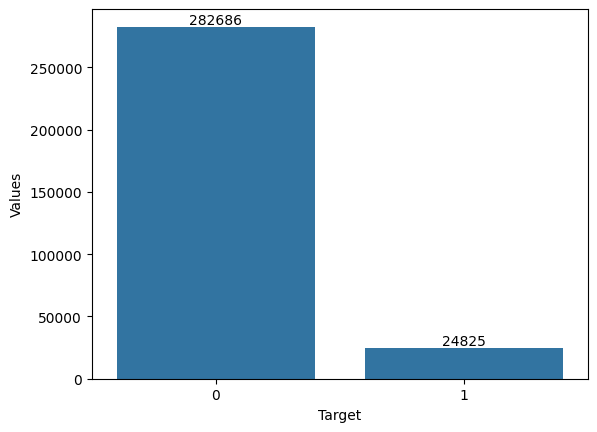

```python
temp = application_train.TARGET.value_counts()
df1 = pd.DataFrame({'Target': temp.index,
                   'Values': temp.values})

ax = sns.barplot(x = 'Target', y="Values", data=df1)
for i in ax.containers:
    ax.bar_label(i,)
plt.show()
```

We should note that the data is itself skewed, hence we need to apply proper strategies while training/testing splits and before coming to any conclusions.

```python
# numerical_cols = list(application_train.columns[application_train.dtypes=='object'])
application_train.describe()
```

|  | SK_ID_CURR | TARGET | CNT_CHILDREN | AMT_INCOME_TOTAL | AMT_CREDIT | AMT_ANNUITY | AMT_GOODS_PRICE | REGION_POPULATION_RELATIVE | DAYS_BIRTH | DAYS_EMPLOYED | ... | FLAG_DOCUMENT_18 | FLAG_DOCUMENT_19 | FLAG_DOCUMENT_20 | FLAG_DOCUMENT_21 | AMT_REQ_CREDIT_BUREAU_HOUR | AMT_REQ_CREDIT_BUREAU_DAY | AMT_REQ_CREDIT_BUREAU_WEEK | AMT_REQ_CREDIT_BUREAU_MON | AMT_REQ_CREDIT_BUREAU_QRT | AMT_REQ_CREDIT_BUREAU_YEAR |
| --- | --- | --- | --- | --- | --- | --- | --- | --- | --- | --- | --- | --- | --- | --- | --- | --- | --- | --- | --- | --- | --- |
| count | 307511.000000 | 307511.000000 | 307511.000000 | 3.075110e+05 | 3.075110e+05 | 307499.000000 | 3.072330e+05 | 307511.000000 | 307511.000000 | 307511.000000 | ... | 307511.000000 | 307511.000000 | 307511.000000 | 307511.000000 | 265992.000000 | 265992.000000 | 265992.000000 | 265992.000000 | 265992.000000 | 265992.000000 |
| mean | 278180.518577 | 0.080729 | 0.417052 | 1.687979e+05 | 5.990260e+05 | 27108.573909 | 5.383962e+05 | 0.020868 | -16036.995067 | 63815.045904 | ... | 0.008130 | 0.000595 | 0.000507 | 0.000335 | 0.006402 | 0.007000 | 0.034362 | 0.267395 | 0.265474 | 1.899974 |
| std | 102790.175348 | 0.272419 | 0.722121 | 2.371231e+05 | 4.024908e+05 | 14493.737315 | 3.694465e+05 | 0.013831 | 4363.988632 | 141275.766519 | ... | 0.089798 | 0.024387 | 0.022518 | 0.018299 | 0.083849 | 0.110757 | 0.204685 | 0.916002 | 0.794056 | 1.869295 |
| min | 100002.000000 | 0.000000 | 0.000000 | 2.565000e+04 | 4.500000e+04 | 1615.500000 | 4.050000e+04 | 0.000290 | -25229.000000 | -17912.000000 | ... | 0.000000 | 0.000000 | 0.000000 | 0.000000 | 0.000000 | 0.000000 | 0.000000 | 0.000000 | 0.000000 | 0.000000 |
| 25% | 189145.500000 | 0.000000 | 0.000000 | 1.125000e+05 | 2.700000e+05 | 16524.000000 | 2.385000e+05 | 0.010006 | -19682.000000 | -2760.000000 | ... | 0.000000 | 0.000000 | 0.000000 | 0.000000 | 0.000000 | 0.000000 | 0.000000 | 0.000000 | 0.000000 | 0.000000 |
| 50% | 278202.000000 | 0.000000 | 0.000000 | 1.471500e+05 | 5.135310e+05 | 24903.000000 | 4.500000e+05 | 0.018850 | -15750.000000 | -1213.000000 | ... | 0.000000 | 0.000000 | 0.000000 | 0.000000 | 0.000000 | 0.000000 | 0.000000 | 0.000000 | 0.000000 | 1.000000 |
| 75% | 367142.500000 | 0.000000 | 1.000000 | 2.025000e+05 | 8.086500e+05 | 34596.000000 | 6.795000e+05 | 0.028663 | -12413.000000 | -289.000000 | ... | 0.000000 | 0.000000 | 0.000000 | 0.000000 | 0.000000 | 0.000000 | 0.000000 | 0.000000 | 0.000000 | 3.000000 |
| max | 456255.000000 | 1.000000 | 19.000000 | 1.170000e+08 | 4.050000e+06 | 258025.500000 | 4.050000e+06 | 0.072508 | -7489.000000 | 365243.000000 | ... | 1.000000 | 1.000000 | 1.000000 | 1.000000 | 4.000000 | 9.000000 | 8.000000 | 27.000000 | 261.000000 | 25.000000 |

8 rows × 106 columns

### Visualizing TARGET wrt some important features

[output not shown]

[output cut: 43 more lines]

[output not shown]

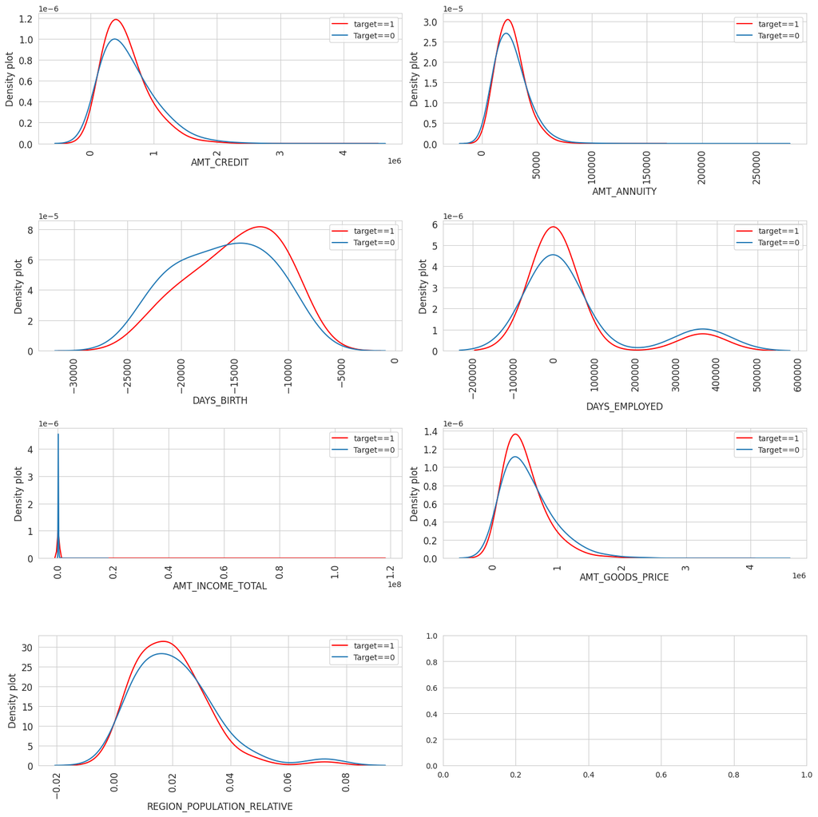

```python
def plot_distribution(df, FEATURES):
    i = 0
    t1 = df.loc[df['TARGET'] != 0]
    t0 = df.loc[df['TARGET'] == 0]

    sns.set_style('whitegrid')
    fig, ax = plt.subplots(4, 2, figsize=(15, 15))

    for feature in FEATURES:
        if feature != 'TARGET':
            i += 1
            plt.subplot(4, 2, i)
            sns.kdeplot(t1[feature], bw=0.5, color='red', label="TARGET = 1")
            sns.kdeplot(t0[feature], bw=0.5, label="default = 0")
            plt.ylabel('Density plot', fontsize=12)
            plt.xlabel(feature, fontsize=12)
            plt.xticks(fontsize=12, rotation=90)  # Set the font size for x-axis labels
            plt.yticks(fontsize=12)  # Set the font size for y-axis labels
            plt.legend(labels=["target==1","Target==0"])

    plt.tight_layout()  # Adjust the spacing between subplots
    plt.show()

domain_features=['AMT_CREDIT','AMT_ANNUITY','DAYS_BIRTH','DAYS_EMPLOYED','AMT_INCOME_TOTAL','AMT_GOODS_PRICE','REGION_POPULATION_RELATIVE']
plot_distribution(application_train,domain_features)
```

### Few observations:

1. We can say that the large amount of credit is not the cause of defaulting and we can explain this by the hard procedures that banks uses for large loans. Also from this plot we find that most of the defaulters have small credits less than one Million Dollar because Banks doesn't put in place complicated procedures to control the small loans as for big loans .
2. The similarity in the shape and mean of the annuity distribution between default==1 and default==0 suggests that, on average, the annuity values for both groups are comparable. This similarity indicates that the average annuity amounts are not significantly different between borrowers who defaulted and those who did not.Also,there is higher likelihood of default cases in the central region. This suggests that there might be an increased likelihood of default for borrowers with annuity values around the peak of the distribution.
3. The target == 1 curve skews towards the younger end of the range,younger peope are more likely to default. The distribution of the days_employed indicates that new employees are more likely to make default.

### Categorical Features

```python
cat_cols = list(application_train.columns[application_train.dtypes=='object'])

for col in cat_cols:
    print(col,application_train[col].nunique())
```

```
NAME_CONTRACT_TYPE 2
CODE_GENDER 3
FLAG_OWN_CAR 2
FLAG_OWN_REALTY 2
NAME_TYPE_SUITE 7
NAME_INCOME_TYPE 8
NAME_EDUCATION_TYPE 5
NAME_FAMILY_STATUS 6
NAME_HOUSING_TYPE 6
OCCUPATION_TYPE 18
WEEKDAY_APPR_PROCESS_START 7
ORGANIZATION_TYPE 58
FONDKAPREMONT_MODE 4
HOUSETYPE_MODE 3
WALLSMATERIAL_MODE 7
EMERGENCYSTATE_MODE 2
```

### Visualization

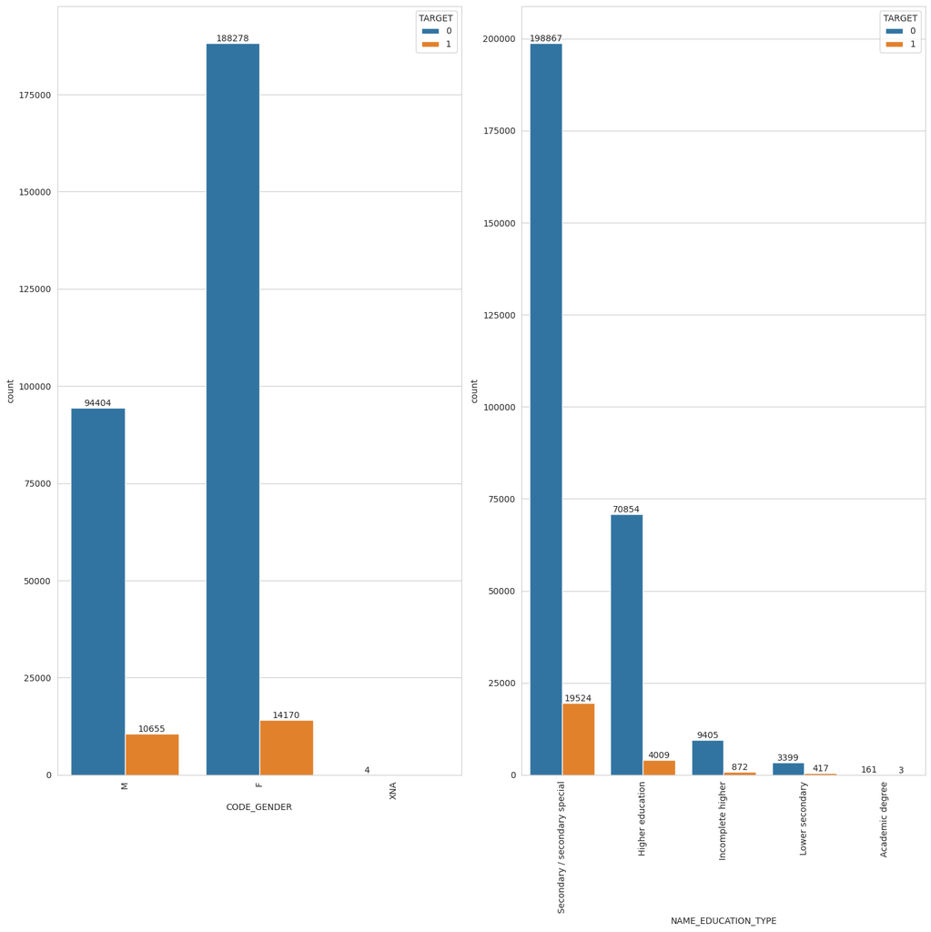

```python
application_train['CODE_GENDER'].value_counts()

# g = sns.catplot(
#     data=application_train, kind="bar",
#     x="CODE_GENDER", y=application_train['CODE_GENDER'].value_counts(),hue="TARGET"
# )
fig, ax = plt.subplots(1, 2, figsize=(15, 15))
plt.subplot(1,2,1)
ax = sns.countplot(x='CODE_GENDER', data=application_train, hue="TARGET",)
plt.xticks(rotation=90)
for i in ax.containers:
    ax.bar_label(i,)
plt.subplot(1,2,2)

ax = sns.countplot(x='NAME_EDUCATION_TYPE', data=application_train, hue="TARGET",)
plt.xticks(rotation=90)

for i in ax.containers:
    ax.bar_label(i,)

plt.tight_layout()  # Adjust the spacing between subplots
plt.show()
```

1. It can be observed that percentage of women defaulting is way less than percentage of men defaulting.
2. People with a low education level shows the most defaulters, in the first place people with less than secondary school. Also people with a hight education level are less prone to default. This feature show a significative difference of the distributions of defaulter and non defaulter so it will be helpfull for the modeling task.

# Cross Validation

```python
# save memory, delete old data
# del application_train
```

```python
# Extract Categorical columns
# cat_cols = list(train_data.columns[train_data.dtypes=='object'])
# len(cat_cols)
```

```python
# Extract numeric columns
# num_cols = list(train_data.columns[train_data.dtypes!='object'])
# len(num_cols)
```

In the given code snippet, we performed feature engineering on the application_train and application_test datasets. The steps involved dropping the 'SK_ID_CURR' column from both datasets, replacing anomalous values (365243) in the 'DAYS_EMPLOYED' column with NaN, and replacing 'XNA' values in the 'CODE_GENDER' column with NaN. These preprocessing steps ensure that the data is cleaned and prepared for further analysis and modeling.

```python
application_train.drop('SK_ID_CURR',inplace=True,axis=1)
application_test.drop('SK_ID_CURR',inplace=True,axis=1)
application_train['DAYS_EMPLOYED'].replace(365243,np.nan,inplace=True)
application_test['DAYS_EMPLOYED'].replace(365243,np.nan,inplace=True)
application_train['CODE_GENDER'].replace('XNA',np.nan,inplace=True)
application_test['CODE_GENDER'].replace('XNA',np.nan,inplace=True)
```

### Handling missing data

We know that missing Data represented in 67 columns and with different proportions from 0% to 70% ,and affects both numeric and categorical features. To tackle this problem our stragegy consists in :

### Handling missing numeric variables

```python
# Detect highly missing numeric features
application_train_numeric= application_train.select_dtypes(include=['number'])
missings=application_train_numeric.loc[:,application_train_numeric.isna().mean() >= 0.6]
highly_missing_features = missings.columns
missings.columns

application_train.drop(highly_missing_features,axis=1,inplace=True)
application_test.drop(highly_missing_features,axis=1,inplace=True)
```

```python
target = application_train['TARGET']
features_train = application_train.drop('TARGET', axis=1)

# Impute numerical features using mean imputation
numeric_imputer = SimpleImputer(strategy='median')
numeric_features_train = features_train.select_dtypes(include='number')
imputed_numeric_features_train = numeric_imputer.fit_transform(numeric_features_train)
numeric_features_test = application_test.select_dtypes(include='number')
imputed_numeric_features_test = numeric_imputer.transform(numeric_features_test)
```

### Handling missing categorical variables

```python
categorical_features_train = features_train.select_dtypes(include='object')
# using dummy_na=False ,we perform onehot encoding without affecting data distribution
dummy_categorical_features_train = pd.get_dummies(categorical_features_train,dummy_na=False)

# Concatenate imputed numerical and categorical features Train
imputed_features_train = pd.concat([pd.DataFrame(imputed_numeric_features_train, columns=numeric_features_train.columns),
                              dummy_categorical_features_train] ,axis=1)

# Impute categorical features Test using mode imputation and one-hot encoding

categorical_features_test = application_test.select_dtypes(include='object')
dummy_categorical_features_test = pd.get_dummies(categorical_features_test,dummy_na=False)

# Concatenate imputed numerical and categorical features
imputed_features_test = pd.concat([pd.DataFrame(imputed_numeric_features_test, columns=numeric_features_test.columns),
                              dummy_categorical_features_test],
                             axis=1)
```

# Model Training and Evaluation

```python
from sklearn.linear_model import LogisticRegression ,SGDClassifier
from sklearn.preprocessing import FunctionTransformer
from sklearn.tree import DecisionTreeClassifier
from sklearn.pipeline import Pipeline #pipeline
from sklearn.impute import SimpleImputer
from sklearn.model_selection import train_test_split
from sklearn.feature_selection import RFE #for feature selection
from imblearn.over_sampling import SMOTE
from sklearn.preprocessing import MinMaxScaler,LabelEncoder
from sklearn.metrics import (f1_score,classification_report,
                             roc_auc_score,confusion_matrix,roc_curve,auc) # evaluatin metrics
from sklearn.model_selection import KFold,RandomizedSearchCV ,cross_val_score,RepeatedStratifiedKFold
from sklearn.discriminant_analysis import LinearDiscriminantAnalysis
from sklearn.naive_bayes import GaussianNB
from sklearn.svm import SVC
from sklearn.ensemble import GradientBoostingClassifier ,RandomForestClassifier

import gc
```

```python
X=imputed_features_train.copy()
y=target
#splitting data to train and test sets
X_train, X_test, y_train, y_test = train_test_split(X, y,stratify=y, test_size=0.25, random_state=27)
```

```python
# Define class weights
class_weights = {0: 1, 1: 9}

simple_estimators = {
                     'Decision Tree':DecisionTreeClassifier(),
                     'Linear Discriminant Analysys': LinearDiscriminantAnalysis()}
```

```python
def training_simple_models(estimators):
    for name, model in estimators.items():
        print("Running " + name)

        # Apply SMOTE oversampling to the training data
        smote = SMOTE()
        X_train_smt, y_train_smt = smote.fit_resample(X_train, y_train)

        # Scaling data
        scaler = MinMaxScaler()
        X_train_scaled= scaler.fit_transform(X_train_smt)
        X_test_scaled=scaler.transform(X_test)

        # Perform Recursive Feature Elimination (RFE)
        selector = RFE(estimator=model)
        X_train_selected = selector.fit_transform(X_train_scaled, y_train_smt)
        X_test_selected = selector.transform(X_test_scaled)

        # Train the model on the selected features
        model.fit(X_train_selected, y_train_smt)

        # Make predictions on the test data
        y_pred = model.predict_proba(X_test_selected)[:, 1]

        # Calculate and print the ROC AUC score
        roc_auc = roc_auc_score(y_test, y_pred)
        print("roc_auc:", roc_auc)
        print('*' * 20)
```

```python
training_simple_models(simple_estimators)
```

[output not shown]

```
Running Decision Tree
```

### Using catboost

```python
# Load data
application_train = pd.read_csv('./application_train.csv')
application_train

application_test = pd.read_csv('./application_test.csv')
application_test
```

|  | SK_ID_CURR | NAME_CONTRACT_TYPE | CODE_GENDER | FLAG_OWN_CAR | FLAG_OWN_REALTY | CNT_CHILDREN | AMT_INCOME_TOTAL | AMT_CREDIT | AMT_ANNUITY | AMT_GOODS_PRICE | ... | FLAG_DOCUMENT_18 | FLAG_DOCUMENT_19 | FLAG_DOCUMENT_20 | FLAG_DOCUMENT_21 | AMT_REQ_CREDIT_BUREAU_HOUR | AMT_REQ_CREDIT_BUREAU_DAY | AMT_REQ_CREDIT_BUREAU_WEEK | AMT_REQ_CREDIT_BUREAU_MON | AMT_REQ_CREDIT_BUREAU_QRT | AMT_REQ_CREDIT_BUREAU_YEAR |
| --- | --- | --- | --- | --- | --- | --- | --- | --- | --- | --- | --- | --- | --- | --- | --- | --- | --- | --- | --- | --- | --- |
| 0 | 100001 | Cash loans | F | N | Y | 0 | 135000.0 | 568800.0 | 20560.5 | 450000.0 | ... | 0 | 0 | 0 | 0 | 0.0 | 0.0 | 0.0 | 0.0 | 0.0 | 0.0 |
| 1 | 100005 | Cash loans | M | N | Y | 0 | 99000.0 | 222768.0 | 17370.0 | 180000.0 | ... | 0 | 0 | 0 | 0 | 0.0 | 0.0 | 0.0 | 0.0 | 0.0 | 3.0 |
| 2 | 100013 | Cash loans | M | Y | Y | 0 | 202500.0 | 663264.0 | 69777.0 | 630000.0 | ... | 0 | 0 | 0 | 0 | 0.0 | 0.0 | 0.0 | 0.0 | 1.0 | 4.0 |
| 3 | 100028 | Cash loans | F | N | Y | 2 | 315000.0 | 1575000.0 | 49018.5 | 1575000.0 | ... | 0 | 0 | 0 | 0 | 0.0 | 0.0 | 0.0 | 0.0 | 0.0 | 3.0 |
| 4 | 100038 | Cash loans | M | Y | N | 1 | 180000.0 | 625500.0 | 32067.0 | 625500.0 | ... | 0 | 0 | 0 | 0 | NaN | NaN | NaN | NaN | NaN | NaN |
| ... | ... | ... | ... | ... | ... | ... | ... | ... | ... | ... | ... | ... | ... | ... | ... | ... | ... | ... | ... | ... | ... |
| 48739 | 456221 | Cash loans | F | N | Y | 0 | 121500.0 | 412560.0 | 17473.5 | 270000.0 | ... | 0 | 0 | 0 | 0 | 0.0 | 0.0 | 0.0 | 0.0 | 0.0 | 1.0 |
| 48740 | 456222 | Cash loans | F | N | N | 2 | 157500.0 | 622413.0 | 31909.5 | 495000.0 | ... | 0 | 0 | 0 | 0 | NaN | NaN | NaN | NaN | NaN | NaN |
| 48741 | 456223 | Cash loans | F | Y | Y | 1 | 202500.0 | 315000.0 | 33205.5 | 315000.0 | ... | 0 | 0 | 0 | 0 | 0.0 | 0.0 | 0.0 | 0.0 | 3.0 | 1.0 |
| 48742 | 456224 | Cash loans | M | N | N | 0 | 225000.0 | 450000.0 | 25128.0 | 450000.0 | ... | 0 | 0 | 0 | 0 | 0.0 | 0.0 | 0.0 | 0.0 | 0.0 | 2.0 |
| 48743 | 456250 | Cash loans | F | Y | N | 0 | 135000.0 | 312768.0 | 24709.5 | 270000.0 | ... | 0 | 0 | 0 | 0 | 0.0 | 0.0 | 0.0 | 0.0 | 1.0 | 4.0 |

48744 rows × 121 columns

```python
# Use catboost because of categorical features
import catboost
from catboost import CatBoostClassifier
```

```python
# use roc_auc_score metric since we are predicting probabilities
from sklearn.metrics import roc_auc_score
```

```python
from sklearn.model_selection import train_test_split
```

```python
# split data into training and validation set
train_data, validation_data = train_test_split(application_train, test_size=0.25, stratify=application_train.TARGET, random_state=42)
print(len(train_data), len(validation_data))
```

```
230633 76878
```

# Training with only *numeric features*, fillna with 0

```python
# Extract Categorical columns
cat_cols = list(train_data.columns[train_data.dtypes=='object'])
len(cat_cols)
```

```
16
```

```python
# Extract numeric columns
num_cols = list(train_data.columns[train_data.dtypes!='object'])
len(num_cols)
```

```
106
```

```python
# check if target is in num_cols
# if it is, delete it because we will be using num_cols for model training
"TARGET" in num_cols
```

```
True
```

```python
num_cols.remove("TARGET")
```

```python
# check if id is in num_cols
# if it is, delete it because we will be using num_cols for model training
"SK_ID_CURR" in num_cols
```

```
True
```

```python
num_cols.remove("SK_ID_CURR")
```

```python
len(num_cols)
```

```
104
```

```python
model = CatBoostClassifier(silent=True,n_estimators=100,cat_features=[])
```

```python
cols = num_cols
na_val = 0
predictions = model.fit(train_data[cols].fillna(na_val), train_data["TARGET"]).predict_proba(validation_data[cols].fillna(na_val))[:,1]
print(roc_auc_score(validation_data["TARGET"],predictions))
```

```
0.7484472369885169
```

The roc_auc_score of 0.7484472369885169 indicates that the model is able to distinguish between positive and negative classes with an accuracy of 74.8%. This is a good score, but it is not perfect. It is important to note that the roc_auc_score is not the only metric that should be used to evaluate a model's performance. Other metrics, such as precision, recall should also be considered. The roc_auc_score can be misleading if the dataset is imbalanced. If the dataset is imbalanced, the model may be able to achieve a high roc_auc_score by simply predicting the majority class.

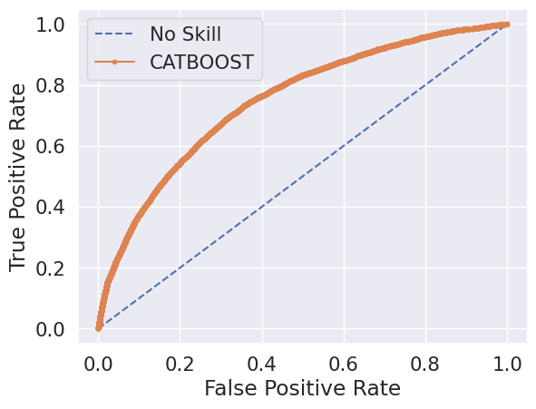

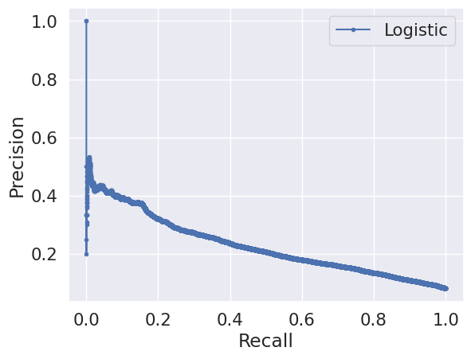

```python
# calculate roc curve for model
# plot no skill roc curve
plt.plot([0, 1], [0, 1], linestyle='--', label='No Skill')
fpr, tpr, _ = roc_curve(validation_data["TARGET"], predictions)
# plot model roc curve
plt.plot(fpr, tpr, marker='.', label='CATBOOST')
# axis labels
plt.xlabel('False Positive Rate')
plt.ylabel('True Positive Rate')
# show the legend
plt.legend()
# show the plot
plt.show()

from sklearn.metrics import precision_recall_curve
precision, recall, _ = precision_recall_curve(validation_data["TARGET"], predictions)
# plot the model precision-recall curve
plt.plot(recall, precision, marker='.', label='Logistic')
# axis labels
plt.xlabel('Recall')
plt.ylabel('Precision')

plt.legend()
# show the plot
plt.show()
```

# Use both *numerical and categorical* features

```python
model = CatBoostClassifier(silent=True,n_estimators=100,cat_features=cat_cols)
```

```python
cols = cat_cols + num_cols
predictions = model.fit(train_data[cols].fillna(na_val), train_data["TARGET"]).predict_proba(validation_data[cols].fillna(na_val))[:,1]
print(roc_auc_score(validation_data["TARGET"],predictions))
```

```
0.7548774388220123
```

The roc_auc_score of 0.7548774388220123 indicates that the model is able to distinguish between positive and negative classes with an accuracy of 75.5%. This is a good score, but it is not perfect. It is important to note that the roc_auc_score is not the only metric that should be used to evaluate a model's performance. Other metrics, such as precision, recall should also be considered. In addition, the ROC AUC score can be misleading if the dataset is imbalanced. If the dataset is imbalanced, the model may be able to achieve a high roc_auc_score by simply predicting the majority class. Therefore, it is important to carefully consider the roc_auc_score in the context of the specific problem that the model is trying to solve. In this case, the roc_auc_score of 0.7548774388220123 suggests that the model is able to distinguish between defaulters and non-defaulters with a reasonable degree of accuracy. However, it is important to note that this score is not perfect, and that the model may still make some incorrect predictions.

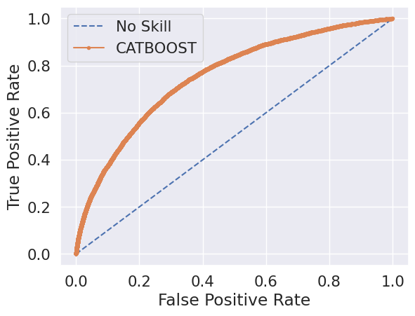

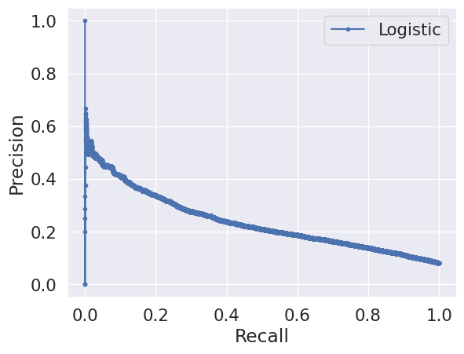

```python
# calculate roc curve for model
# plot no skill roc curve
plt.plot([0, 1], [0, 1], linestyle='--', label='No Skill')
fpr, tpr, _ = roc_curve(validation_data["TARGET"], predictions)
# plot model roc curve
plt.plot(fpr, tpr, marker='.', label='CATBOOST')
# axis labels
plt.xlabel('False Positive Rate')
plt.ylabel('True Positive Rate')
# show the legend
plt.legend()
# show the plot
plt.show()

from sklearn.metrics import precision_recall_curve
precision, recall, _ = precision_recall_curve(validation_data["TARGET"], predictions)
# plot the model precision-recall curve
plt.plot(recall, precision, marker='.', label='Logistic')
# axis labels
plt.xlabel('Recall')
plt.ylabel('Precision')

plt.legend()
# show the plot
plt.show()
```

roc_auc_score is a metric that is used to evaluate the performance of a classification model. It is a measure of how well the model can distinguish between positive and negative classes. The roc_auc_score is calculated by plotting the true positive rate (TPR) against the false positive rate (FPR) at different thresholds. The TPR is the proportion of positive samples that are correctly classified, while the FPR is the proportion of negative samples that are incorrectly classified. The ROC AUC score is the area under the roc curve, and it ranges from 0 to 1. A score of 1 indicates that the model is able to perfectly distinguish between positive and negative classes, while a score of 0 indicates that the model is unable to distinguish between the two classes. roc_auc_score can be used with both numeric and categorical features. For numeric features, the roc_auc_score is calculated by binning the feature values and then calculating the TPR and FPR for each bin. For categorical features, the roc_auc_score is calculated by creating a one-hot encoding of the feature values and then calculating the TPR and FPR for each category. Using roc_auc_score with both numeric and categorical features allows for a more comprehensive evaluation of the model's performance. By considering both types of features, the roc_auc_score can provide a more accurate assessment of the model's ability to distinguish between positive and negative classes.

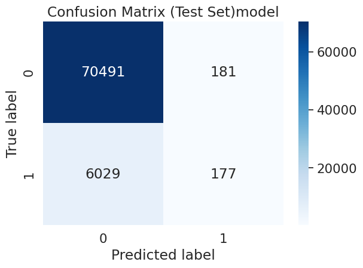

```python
preds = model.predict(validation_data[cols].fillna(na_val))
preds

confusion_matrix_test = confusion_matrix(validation_data["TARGET"], preds)

sns.set(font_scale=1.4)
sns.heatmap(confusion_matrix_test, annot=True, fmt='g', cmap='Blues')
plt.xlabel('Predicted label')
plt.ylabel('True label')
plt.title('Confusion Matrix (Test Set)model');

plt.tight_layout()
plt.show()
```

Since columns of test and train is same so used one of them

The confusion matrix shows that the model is able to correctly classify the majority of samples, with 70,491 true negatives and 177 true positives. However, it also misclassifies a significant number of samples, with 6,029 false negatives and 181 false positives. This suggests that the model may need to be further tuned in order to improve its performance.

# SUBMISSION FILE -

```python
submit = application_test[['SK_ID_CURR']]
submit['TARGET'] = model.predict_proba(application_test[cols].fillna(na_val))[:,1]
submit.to_csv('submission_LR.csv', index = False)
```